# Dynamic_NicheNet

Heesoo Song

2022 2 21

# 0. Install/Load packages

```r
#install.packages("devtools")
#install.packages("htmltools")
#BiocManager::install("limma")
#devtools::install_github("saeyslab/nichenetr")
#install.packages("tidyverse")
```

```r
library(nichenetr)
library(tidyverse)
library(Matrix)
library(dplyr)
```

# 1. Load datasets

**Prior model** Numbers in the ligand-target matrix represents the ligand-target regulatory potential scores between all pairs of ligands and target genes. These scores are calculated using network propagation methods on the integrated networks to propagate the signal from a ligand, over receptors, signaling proteins and transcriptional regulators, to end at target genes.

```r
# Load ligand-target prior model
ligand_target_matrix = readRDS(url("https://zenodo.org/record/5884439/files/ligand_target_matrix_nsga2r_final_mouse.rds"))  # New version
#ligand_target_matrix = readRDS(url("https://zenodo.org/record/3260758/files/ligand_target_matrix.rds"))  # Old version
ligand_target_matrix[1:5, 1:5]
```

```
##               2300002M23Rik 2610528A11Rik 9530003J23Rik            a
## 0610005C13Rik  0.000000e+00  0.000000e+00  0.0000000000 0.0000000000
## 0610009B22Rik  0.000000e+00  0.000000e+00  0.0000000000 0.0000000000
## 0610009L18Rik  9.405222e-05  4.468876e-05  0.0006761845 0.0000676873
## 0610010F05Rik  1.381440e-03  5.292069e-04  0.0024718582 0.0010227684
## 0610010K14Rik  1.932650e-03  4.088630e-04  0.0028872898 0.0011290594
##                        A2m
## 0610005C13Rik 0.0000000000
## 0610009B22Rik 0.0000000000
## 0610009L18Rik 0.0001239123
## 0610010F05Rik 0.0019221743
## 0610010K14Rik 0.0016382756
```

```r
# Load processed expression data of interacting cells
hepa_rds <- readRDS("C:/Users/pc/Desktop/MastersProject/Dynamic_NicheNet/seurat_obj_phx_25102021.rds")
hepa_cluster <- read.csv("C:/Users/pc/Desktop/MastersProject/Dynamic_NicheNet/DE_pseudobulk_cluster.csv")
head(hepa_cluster)
```

```
##                Row.names    logFC.X1  logFC.X2    logFC.X3  logFC.X4
## 1 9930111J21Rik2_kupffer -0.04004515 1.5672714 -1.44737108  2.009087
## 2        A1bg_hepatocyte -2.87375633 0.6497602  3.44178000 -3.933906
## 3           A1cf_kupffer -0.37607693 2.7617716  0.06823805  2.526111
## 4       AA388235_kupffer  3.49354557 4.8715343  0.91539885  2.989688
## 5       AA465934_kupffer  2.59916847 4.8082724  3.81439528  2.330033
## 6      AA465934_stellate  3.50105760 1.8799892  3.15475061  1.097944
##        logCPM        F       PValue        FDR cluster_number
## 1  4.48023395 9.581536 0.0002362206 0.01467333              3
## 2 -1.64784242 5.467550 0.0045189602 0.04987329              2
## 3 -1.51215127 5.572741 0.0041383337 0.04786751              3
## 4 -2.63326285 6.245444 0.0024004929 0.03749350              3
## 5  1.31606859 6.796780 0.0023312265 0.03710324              3
## 6  0.05268207 6.712915 0.0016728833 0.03234660              1
```

```r
# Preprocess cluster data
## Assign clear rownames
rownames(hepa_cluster) <- NULL
hepa_cluster <- hepa_cluster %>% column_to_rownames(var="Row.names")

## Add celltype & Symbol columns to cluster matrix
extract_geneID <- as.data.frame(str_split(rownames(hepa_cluster), "_", simplify=TRUE))
hepa_cluster$Symbol <- extract_geneID$V1
hepa_cluster$celltype <- extract_geneID$V2
head(hepa_cluster)
```

```
##                           logFC.X1  logFC.X2    logFC.X3  logFC.X4      logCPM
## 9930111J21Rik2_kupffer -0.04004515 1.5672714 -1.44737108  2.009087  4.48023395
## A1bg_hepatocyte        -2.87375633 0.6497602  3.44178000 -3.933906 -1.64784242
## A1cf_kupffer           -0.37607693 2.7617716  0.06823805  2.526111 -1.51215127
## AA388235_kupffer        3.49354557 4.8715343  0.91539885  2.989688 -2.63326285
## AA465934_kupffer        2.59916847 4.8082724  3.81439528  2.330033  1.31606859
## AA465934_stellate       3.50105760 1.8799892  3.15475061  1.097944  0.05268207
##                               F       PValue        FDR cluster_number
## 9930111J21Rik2_kupffer 9.581536 0.0002362206 0.01467333              3
## A1bg_hepatocyte        5.467550 0.0045189602 0.04987329              2
## A1cf_kupffer           5.572741 0.0041383337 0.04786751              3
## AA388235_kupffer       6.245444 0.0024004929 0.03749350              3
## AA465934_kupffer       6.796780 0.0023312265 0.03710324              3
## AA465934_stellate      6.712915 0.0016728833 0.03234660              1
##                                Symbol   celltype
## 9930111J21Rik2_kupffer 9930111J21Rik2    kupffer
## A1bg_hepatocyte                  A1bg hepatocyte
## A1cf_kupffer                     A1cf    kupffer
## AA388235_kupffer             AA388235    kupffer
## AA465934_kupffer             AA465934    kupffer
## AA465934_stellate            AA465934   stellate
```

```r
# Preprocess expression data
## Subset to seven cell-types
celltype_OI <- c("cholangiocyte","endothelial","hepatocyte","kupffer","monocyte","neutrophil","stellate")
hepa_celltypeOI <- subset(x = hepa_rds, idents = celltype_OI)

## Factorize experiment timepoint
experiments <- c("0_phase_1", "3_phase_2", "6_phase_2", "12_phase_2", "24_phase_2", "36_phase_2", "48_phase_1", "48_phase_2", "72_phase_2", "96_phase_2", "120_phase_2", "168_phase_2")
hours <- c(0, 3, 6, 12, 24, 36, 48, 48, 72, 96, 120, 168)
hepa_celltypeOI@meta.data$time_experiment <- factor(hepa_celltypeOI@meta.data$time_experiment, levels = experiments)
```

```r
hepa_sample_info <- hepa_celltypeOI@meta.data
hepa_expression <- t(hepa_celltypeOI@assays$RNA@counts)
hepa_expression[1:5, 1:5]
```

```
## 5 x 5 sparse Matrix of class "dgCMatrix"
##                             ENSMUSG00000071302 ENSMUSG00000069893
## AAACCCATCCGCGATG.FSV1_3h_s1                  .                  .
## AAACGAAAGAATTGCA.FSV1_3h_s1                  .                  .
## AAACGCTAGTCACTGT.FSV1_3h_s1                  1                  .
## AAAGGATCAATTGAGA.FSV1_3h_s1                  .                  .
## AAAGGTAAGGCTTAGG.FSV1_3h_s1                  .                  .
##                             ENSMUSG00000069892 ENSMUSG00000027596
## AAACCCATCCGCGATG.FSV1_3h_s1                  .                  .
## AAACGAAAGAATTGCA.FSV1_3h_s1                  1                  .
## AAACGCTAGTCACTGT.FSV1_3h_s1                  1                  .
## AAAGGATCAATTGAGA.FSV1_3h_s1                  .                  .
## AAAGGTAAGGCTTAGG.FSV1_3h_s1                  .                  .
##                             ENSMUSG00000022347
## AAACCCATCCGCGATG.FSV1_3h_s1                  .
## AAACGAAAGAATTGCA.FSV1_3h_s1                  .
## AAACGCTAGTCACTGT.FSV1_3h_s1                  .
## AAAGGATCAATTGAGA.FSV1_3h_s1                  .
## AAAGGTAAGGCTTAGG.FSV1_3h_s1                  .
```

```r
## change ENSEMBL to gene symbol in column names

library(biomaRt)
ensembl <- useEnsembl(biomart="ensembl", dataset = "mmusculus_gene_ensembl")
```

```
## Ensembl site unresponsive, trying uswest mirror
```

```r
IDtoSymbol_matrix <- getBM(attributes=c("ensembl_gene_id","external_gene_name"), filters = "ensembl_gene_id", values = unique(colnames(hepa_expression)), mart = ensembl)
```

```r
expression_colnames <- data.frame(colnames(hepa_expression))
expression_colnames["order"] <- c(1:dim(expression_colnames)[1])
symbol_list <- merge(expression_colnames, IDtoSymbol_matrix,by.x = "colnames.hepa_expression.", by.y = "ensembl_gene_id", all.x = TRUE)

## Fill rest of NA with ENSEMBL ID (ID no longer in the ENSEMBL database)
symbol_list$external_gene_name[is.na(symbol_list$external_gene_name)] <- symbol_list$colnames.hepa_expression.[is.na(symbol_list$external_gene_name)]
symbol_list <- symbol_list[order(symbol_list$order),]

## In old version, the gene names are in uppercase characters, while the new version is not.
### New version
colnames(hepa_expression) <- symbol_list$external_gene_name

### Old version
#colnames(hepa_expression) <- casefold(symbol_list$external_gene_name, upper=TRUE)
#hepa_cluster$Symbol <- casefold(hepa_cluster$Symbol, upper=TRUE)
```

# 2. Define expressed genes

```r
sender_celltype <- "hepatocyte"
receiver_celltype <- "hepatocyte"
sender_timepoint <- "0_phase_1"
receiver_timepoint <- "12_phase_2"
cluster_number <- 1

# Extract sender & receiver cells
sender_ids <- row.names(hepa_sample_info[which(hepa_sample_info$celltype == sender_celltype & hepa_sample_info$time_experiment == sender_timepoint),])
receiver_ids <- row.names(hepa_sample_info[which(hepa_sample_info$celltype == receiver_celltype & hepa_sample_info$time_experiment == receiver_timepoint),])

# Define expressed genes
expressed_genes_sender <- colSums(hepa_expression[sender_ids,] != 0) %>% sapply(function(x){x/length(sender_ids)*100}) %>% .[. >= 10] %>% names()
expressed_genes_receiver <- colSums(hepa_expression[receiver_ids,] != 0) %>% sapply(function(x){x/length(sender_ids)*100}) %>% .[. >= 10] %>% names()
```

# 3. Define gene set of interest and background of genes

This step highly depend on the research question. Gene set of interest are the genes in the target cell population that are potentially affected by ligands expressed by signaling cells.In this research, gene set of interest is genes that are showing similar temporal trend in the receiver cell type. Background expressed genes in this research are all genes from the receiver cell type.

```r
geneset_oi_raw <- hepa_cluster$Symbol[hepa_cluster$celltype == receiver_celltype & hepa_cluster$cluster_number == cluster_number]
geneset_oi <- hepa_cluster$Symbol[hepa_cluster$celltype == receiver_celltype & hepa_cluster$cluster_number == cluster_number] %>% .[. %in% rownames(ligand_target_matrix)] # only consider genes that are present in the NicheNet model

# Disappeared genes
geneset_oi_raw[!geneset_oi_raw %in% geneset_oi]
```

```
## [1] "Cep112os1" "H2ac24"    "Obox8"
```

```r
background_expressed_genes <- expressed_genes_receiver %>% .[. %in% rownames(ligand_target_matrix)]
```

# 4. Define a set of potential ligands

Putative ligand-receptor links were gathered from NicheNet’s ligand-receptor data sources.

```r
lr_network = readRDS(url("https://zenodo.org/record/5884439/files/lr_network_mouse_21122021.rds")) # new version
#lr_network = readRDS(url("https://zenodo.org/record/3260758/files/lr_network.rds")) # old version

ligands = lr_network %>% pull(from) %>% unique()
expressed_ligands = intersect(ligands,expressed_genes_sender)

receptors = lr_network %>% pull(to) %>% unique()
expressed_receptors = intersect(receptors,expressed_genes_receiver)

lr_network_expressed = lr_network %>% filter(from %in% expressed_ligands & to %in% expressed_receptors)
head(lr_network_expressed)
```

```
## # A tibble: 6 x 4
##   from   to      database source
##   <chr>  <chr>   <chr>    <chr>
## 1 Abca1  Apoa1   omnipath omnipath
## 2 Adam10 App     omnipath omnipath
## 3 Adam10 Notch2  omnipath omnipath
## 4 Adam10 Tspan33 omnipath omnipath
## 5 Adam17 Il6ra   omnipath omnipath
## 6 Adam17 Itga5   omnipath omnipath
```

```r
potential_ligands = lr_network_expressed %>% pull(from) %>% unique()
head(potential_ligands)
```

```
## [1] "Abca1"  "Adam10" "Adam17" "Adam9"  "Agt"    "Ahsg"
```

# 5. Perform NicheNet’s ligand activity analysis on the gene set of interest

predict ligand activities = ranks ligands according to how well their prior target gene predictions correspond to the observed gene expression changes. In other words, assess how well each sender_cell-ligand can predict the receiver_cell gene set compared to the background of expressed genes (predict whether a gene belongs to the receiver_cell program or not)

The true ligand with which the cells were treated should predict the differential expression observed in a dataset better than the other ligands. In other words, informative feature importance scores (=measure for ligand activity) should be higher for this ligand (genes of interest) than for others(background genes). The feature importance measures were calculated for each ligand separately.

Next, evaluate how well the feature importance scores of each dataset-ligand combination can predict the correct ligand activity state. Binary classification. For a specific ligand-dataset combination, classified “active” if the dataset contains expression data of cells treated with that ligand. Then classification evaluatino metrics (AUROC, AUPR, and PCC) are calculated.

**Compare this result with random prediction**

```r
# Prediction (not ranked yet)
ligand_activities = predict_ligand_activities(geneset = geneset_oi, background_expressed_genes = background_expressed_genes, ligand_target_matrix = ligand_target_matrix, potential_ligands = potential_ligands)

# Rank the prediction
ligand_activities %>% arrange(-aupr)
```

```
## # A tibble: 159 x 4
##    test_ligand auroc   aupr pearson
##    <chr>       <dbl>  <dbl>   <dbl>
##  1 Angptl4     0.757 0.228   0.429
##  2 Fgf1        0.664 0.134   0.299
##  3 Igf1        0.693 0.123   0.225
##  4 Sema4g      0.663 0.112   0.152
##  5 Grn         0.649 0.0615  0.0613
##  6 Nectin2     0.644 0.0556  0.0204
##  7 Cdh1        0.613 0.0532  0.0748
##  8 Ptdss1      0.610 0.0511  0.0719
##  9 F2          0.624 0.0498  0.0325
## 10 AU040320    0.638 0.0496  0.0730
## # ... with 149 more rows
```

```r
best_upstream_ligands = ligand_activities %>% top_n(20, aupr) %>% arrange(-aupr) %>% pull(test_ligand) %>% unique()
```

```r
#write.table(ligand_activities, file="C:/Users/pc/Desktop/MastersProject/Dynamic_NicheNet/Ligand_Activity_Prediction_AUPR_NicheNet_v2.csv", sep = ",")
```

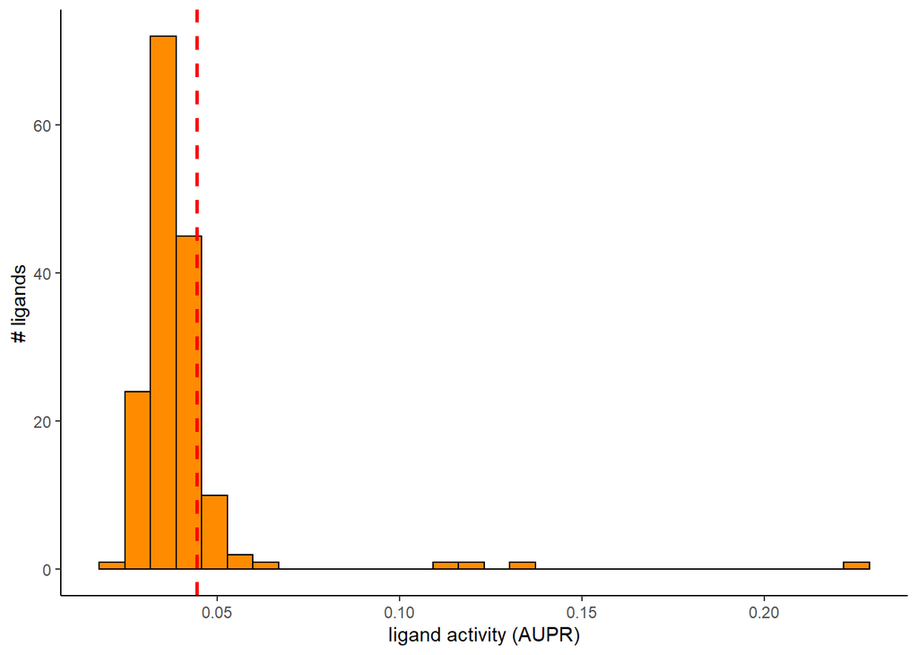

```r
# show histogram of ligand activity scores
p_hist_lig_activity = ggplot(ligand_activities, aes(x=aupr)) +
  geom_histogram(color="black", fill="darkorange")  +
  # geom_density(alpha=.1, fill="orange") +
  geom_vline(aes(xintercept=min(ligand_activities %>% top_n(20, aupr) %>% pull(aupr))), color="red", linetype="dashed", size=1) +
  labs(x="ligand activity (AUPR)", y = "# ligands") +
  theme_classic()
p_hist_lig_activity
```

# 6. Infer target genes of top-ranked ligands and visualize in a heatmap

## 1) infer target genes

If you consider more than the top 250 targets, you will infer more, but less confident ligand-target links.

```r
active_ligand_target_links_df = best_upstream_ligands %>% lapply(get_weighted_ligand_target_links, geneset = geneset_oi, ligand_target_matrix = ligand_target_matrix, n = 250) %>% bind_rows() %>% drop_na()

nrow(active_ligand_target_links_df)
```

```
## [1] 216
```

```r
head(active_ligand_target_links_df)
```

```
## # A tibble: 6 x 3
##   ligand target    weight
##   <chr>  <chr>      <dbl>
## 1 Fgf1   Arhgap11a 0.0515
## 2 Fgf1   Cip2a     0.0524
## 3 Fgf1   Kif15     0.0515
## 4 Fgf1   Kif4      0.0520
## 5 Fgf1   Spdl1     0.0517
## 6 Igf1   Aspm      0.190
```

## 2) Set cutoff for visualization

Lowering the quantile cutoff (0.25) will result in a more dense heatmap, whereas highering this cutoff will result in a more sparse heatmap.

```r
# visualization
active_ligand_target_links = prepare_ligand_target_visualization(ligand_target_df = active_ligand_target_links_df, ligand_target_matrix = ligand_target_matrix, cutoff = 0.25) # score below threshold will be set as 0

head(active_ligand_target_links_df)
```

```
## # A tibble: 6 x 3
##   ligand target    weight
##   <chr>  <chr>      <dbl>
## 1 Fgf1   Arhgap11a 0.0515
## 2 Fgf1   Cip2a     0.0524
## 3 Fgf1   Kif15     0.0515
## 4 Fgf1   Kif4      0.0520
## 5 Fgf1   Spdl1     0.0517
## 6 Igf1   Aspm      0.190
```

## 3) Plot putatively active ligand-target links

The order of the ligands accord to the ranking of the ligand activity prediction.

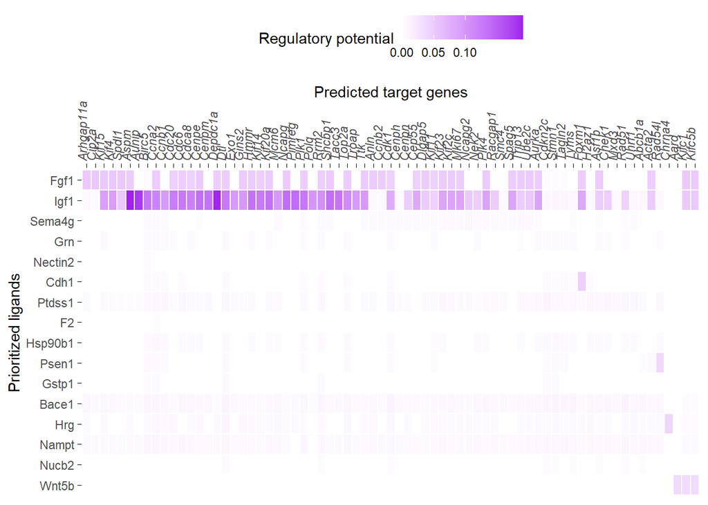

```r
order_ligands = intersect(best_upstream_ligands, colnames(active_ligand_target_links)) %>% rev()
order_targets = active_ligand_target_links_df$target %>% unique()
vis_ligand_target = active_ligand_target_links[order_targets,order_ligands] %>% t()

p_ligand_target_network = vis_ligand_target %>% make_heatmap_ggplot("Prioritized ligands","Predicted target genes", color = "purple",legend_position = "top", x_axis_position = "top",legend_title = "Regulatory potential") + scale_fill_gradient2(low = "whitesmoke",  high = "purple", breaks = c(0,0.05,0.10)) + theme(axis.text.x = element_text(face = "italic"))
p_ligand_target_network
```

# 7. Validation

## 1) Ligand-receptor network inference for top-ranked ligands

Look at which receptors of the receiver cell population can potentially bind to the prioritized ligands from the sender cell population

```r
# get the ligand-receptor network of the top-ranked ligands
lr_network_top = lr_network %>% filter(from %in% best_upstream_ligands & to %in% expressed_receptors) %>% distinct(from,to)
best_upstream_receptors = lr_network_top %>% pull(to) %>% unique()

# get the weights of the ligand-receptor interactions as used in the NicheNet model
weighted_networks = readRDS(url("https://zenodo.org/record/5884439/files/weighted_networks_nsga2r_final_mouse.rds")) # New version
#weighted_networks = readRDS(url("https://zenodo.org/record/3260758/files/weighted_networks.rds")) # Old version
lr_network_top_df = weighted_networks$lr_sig %>% filter(from %in% best_upstream_ligands & to %in% best_upstream_receptors)

# convert to a matrix
lr_network_top_df = lr_network_top_df %>% spread("from","weight",fill = 0)
lr_network_top_matrix = lr_network_top_df %>% dplyr::select(-to) %>% as.matrix() %>% magrittr::set_rownames(lr_network_top_df$to)

# perform hierarchical clustering to order the ligands and receptors
# hierarchical clustering groups similar objects into clusters
# Ward.D2 = Ward algorithm = creates groups such that variance is minimized within clusters. Dissimilarities are squared before clustering.
dist_receptors = dist(lr_network_top_matrix, method = "binary")
hclust_receptors = hclust(dist_receptors, method = "ward.D2")
order_receptors = hclust_receptors$labels[hclust_receptors$order]

dist_ligands = dist(lr_network_top_matrix %>% t(), method = "binary")
hclust_ligands = hclust(dist_ligands, method = "ward.D2")
order_ligands_receptor = hclust_ligands$labels[hclust_ligands$order]
```

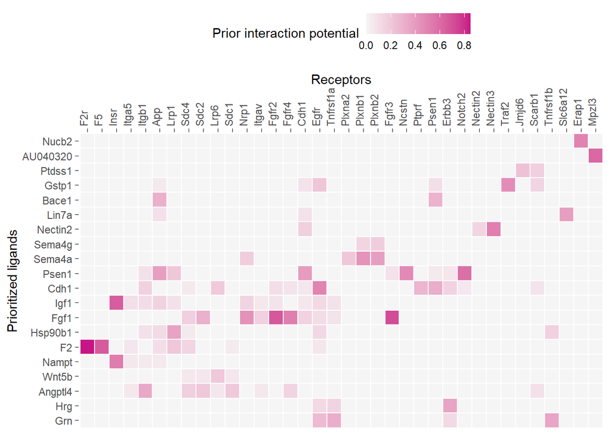

```r
vis_ligand_receptor_network = lr_network_top_matrix[order_receptors, order_ligands_receptor]
p_ligand_receptor_network = vis_ligand_receptor_network %>% t() %>% make_heatmap_ggplot("Prioritized ligands","Receptors", color = "mediumvioletred", x_axis_position = "top",legend_title = "Prior interaction potential")
p_ligand_receptor_network
```

## 2) Visualize expression of top-predicted ligands and their target genes in a combined heatmap

Further look at expression of ligands & target genes. Combine plots of ligand activity, ligand expression, target gene expression, and ligand-target regulatory potential.

```r
library(RColorBrewer)
library(cowplot)
library(ggpubr)
```

**ligand activity matrix**

```r
ligand_aupr_matrix = ligand_activities %>% dplyr::select(aupr) %>% as.matrix() %>% magrittr::set_rownames(ligand_activities$test_ligand)

vis_ligand_aupr = ligand_aupr_matrix[order_ligands, ] %>% as.matrix(ncol = 1) %>% magrittr::set_colnames("AUPR")
```

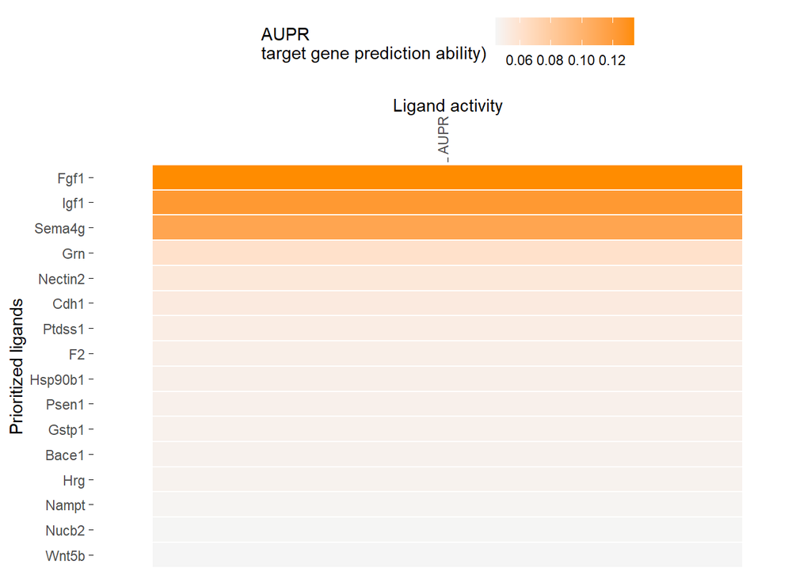

```r
p_ligand_aupr = vis_ligand_aupr %>% make_heatmap_ggplot("Prioritized ligands","Ligand activity", color = "darkorange",legend_position = "top", x_axis_position = "top", legend_title = "AUPR\ntarget gene prediction ability)")
p_ligand_aupr
```

# 8. Gene Interpretation

## 1) Temporal trends

```r
logCPM.obs = read.csv("C:/Users/pc/Desktop/MastersProject/Dynamic_NicheNet/DE_geneID+celltype_logCPM-obs.csv")
logCPM.fit = read.csv("C:/Users/pc/Desktop/MastersProject/Dynamic_NicheNet/DE_geneID+celltype_logCPM-fit.csv")
```

```r
plot_trend <- function(interesting_genes, celltype){
  par(mfrow=c(2,3))

  for(gene in interesting_genes) {
    gene_celltype <- paste0(gene, "_", celltype)
    logCPM.obs.i <- logCPM.obs[gene_celltype,]
    logCPM.fit.i <- logCPM.fit[gene_celltype,]
    plot(hours, logCPM.obs.i, ylab="log-CPM", main=gene_celltype, pch=16)
    lines(hours, logCPM.fit.i, col="red", lwd=2)
  }
}
```

**Active Ligands**

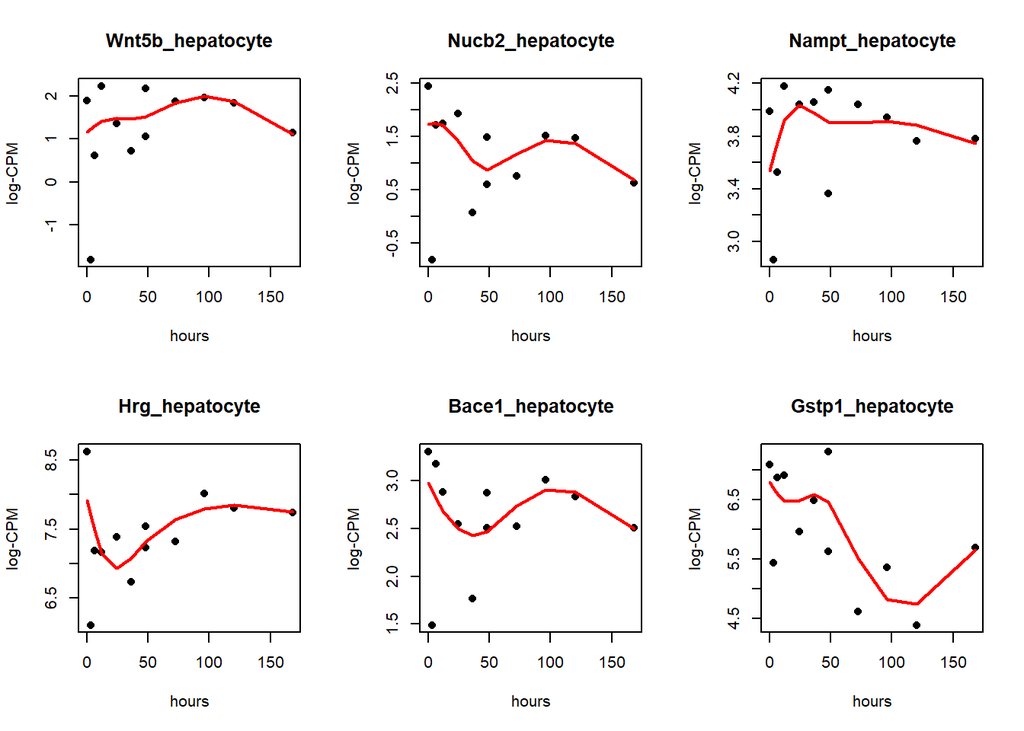

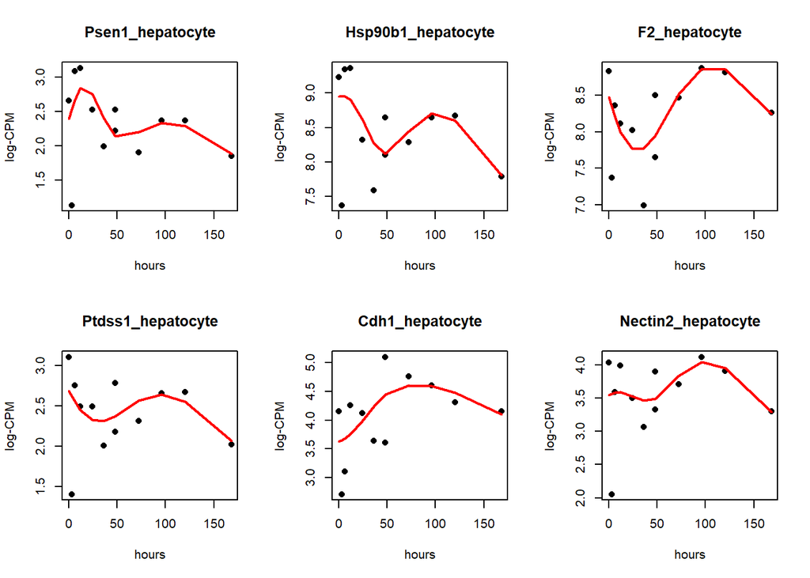

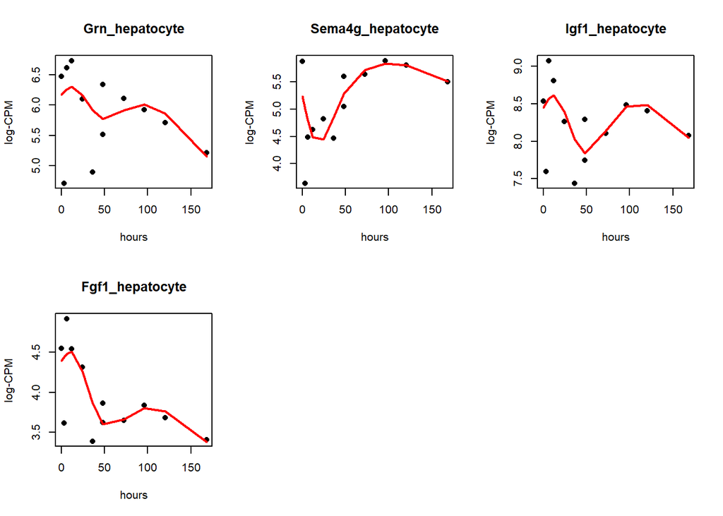

```r
plot_trend(order_ligands, sender_celltype)
```

**Active Targets**

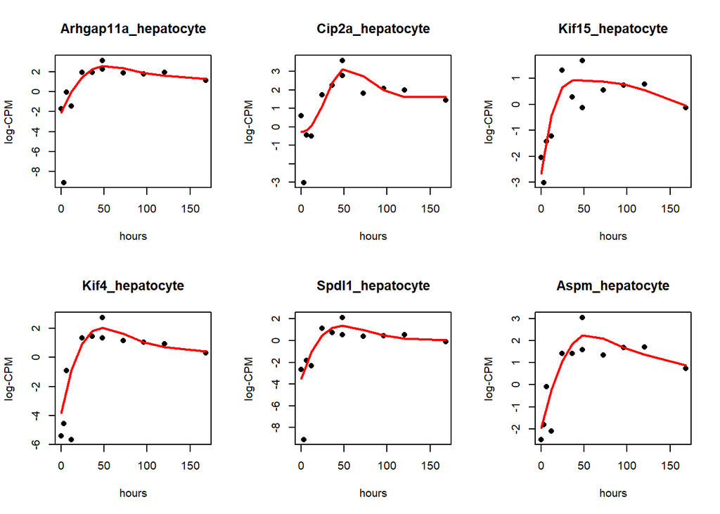

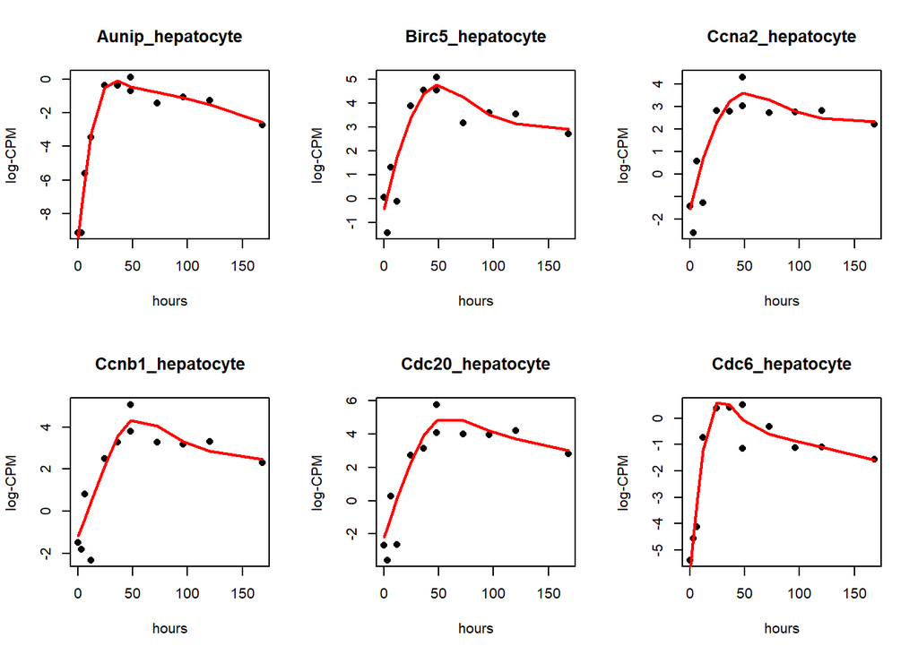

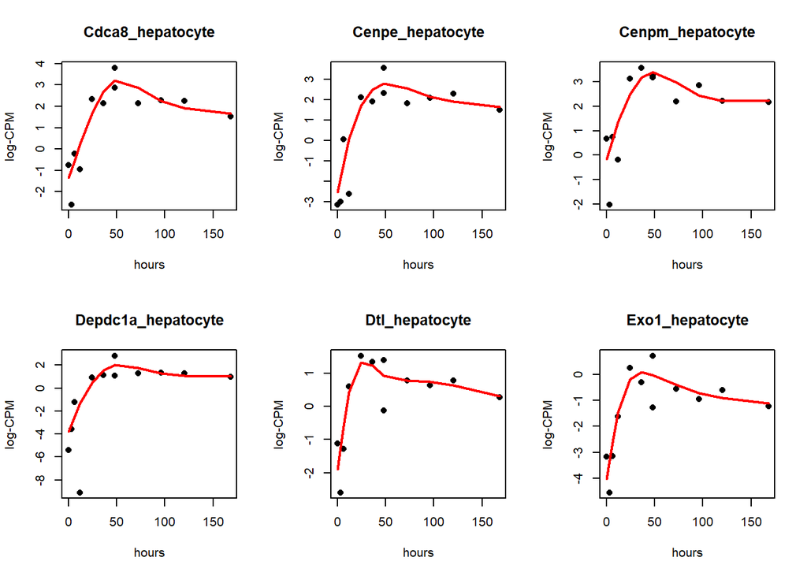

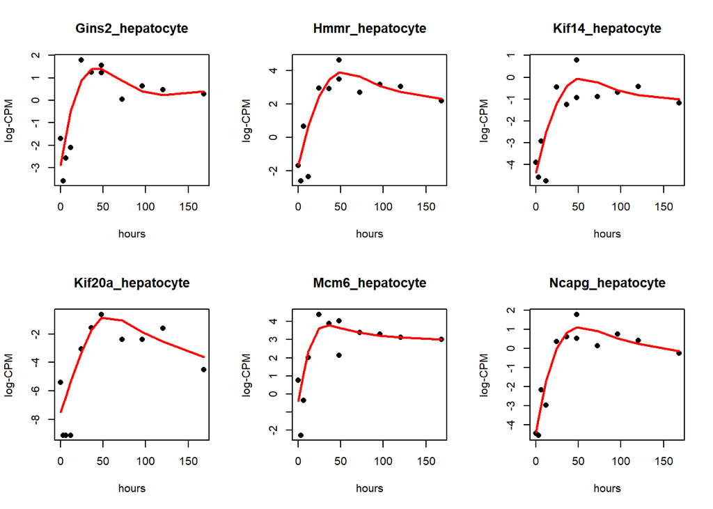

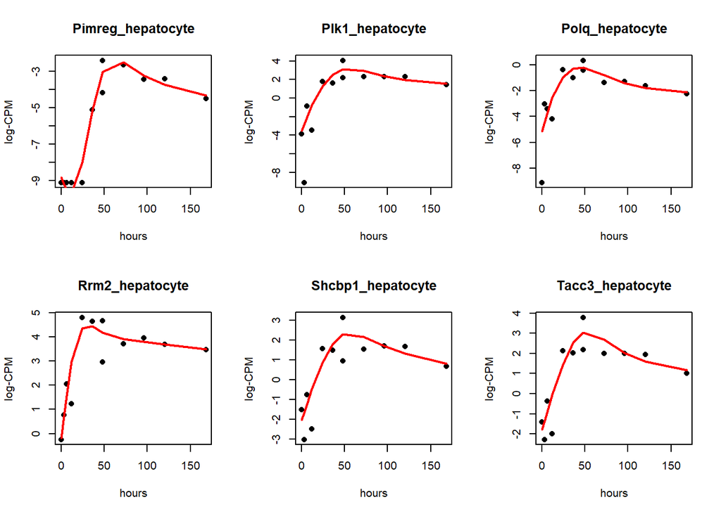

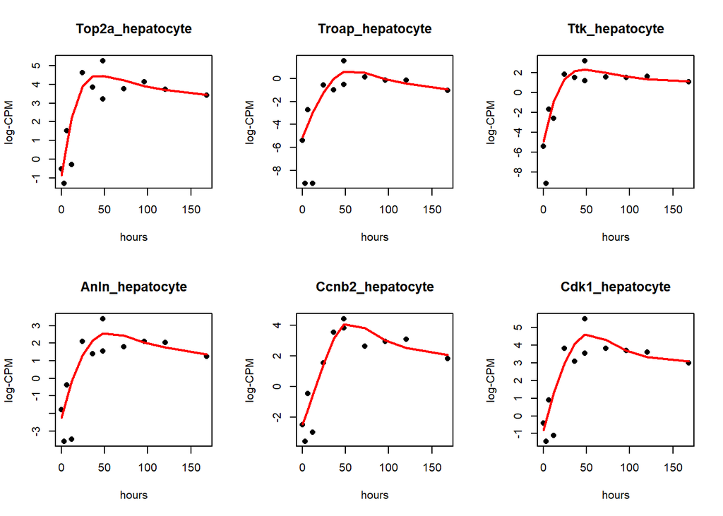

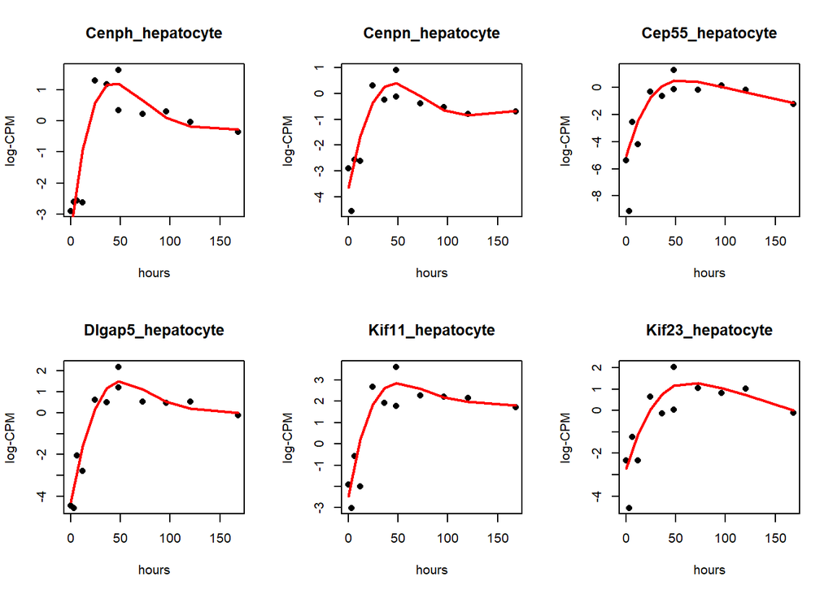

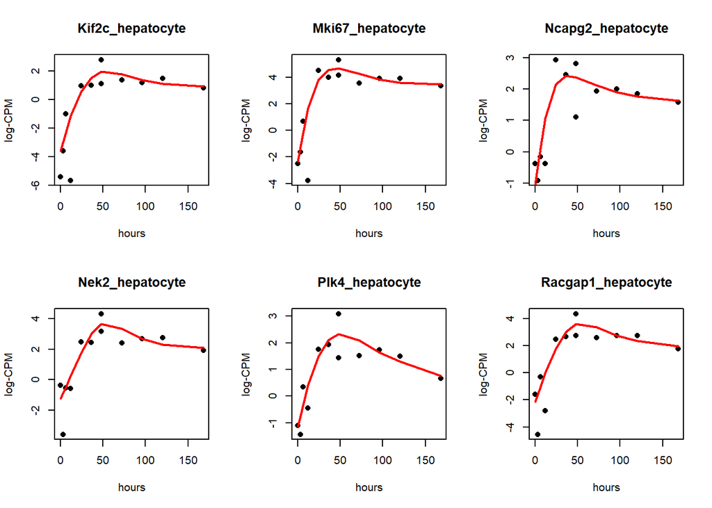

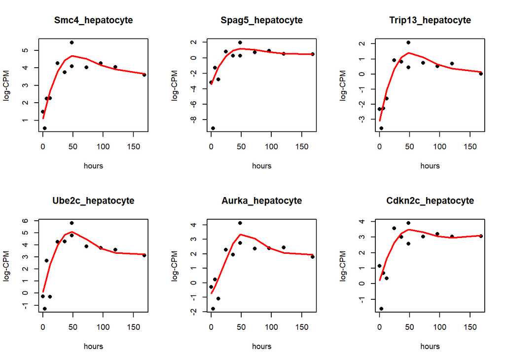

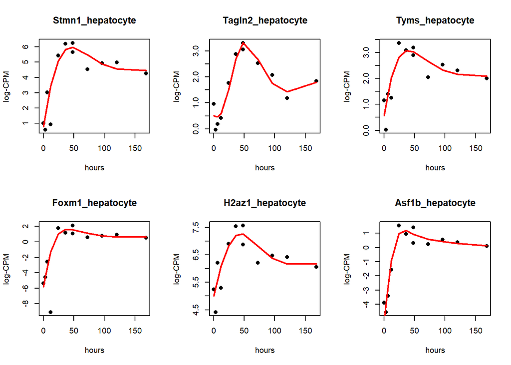

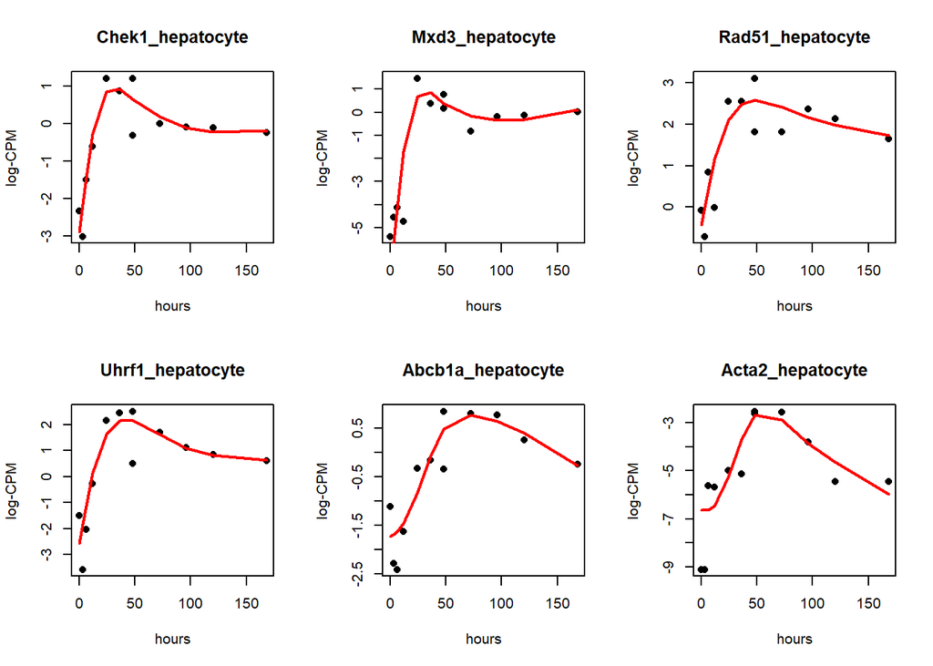

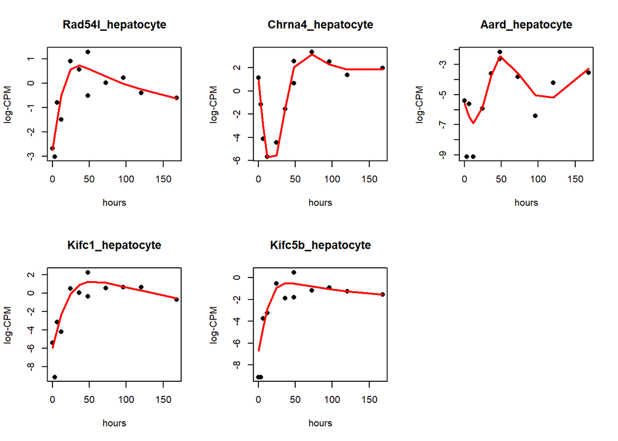

```r
plot_trend(order_targets, receiver_celltype)
```

**Receptors**

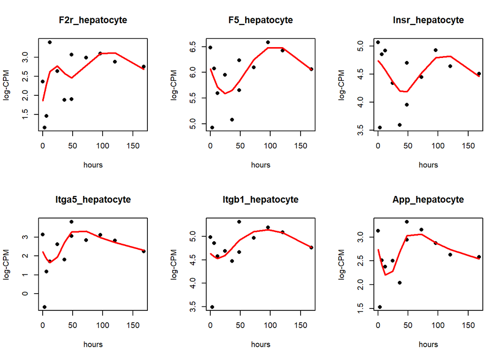

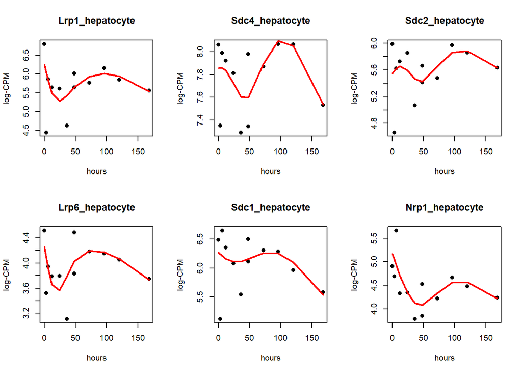

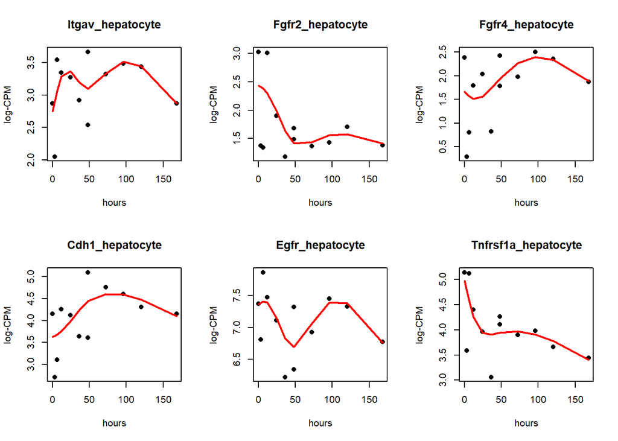

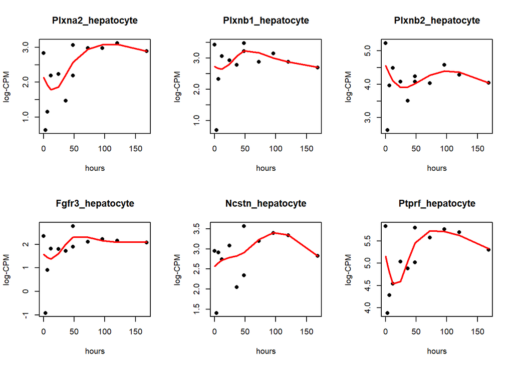

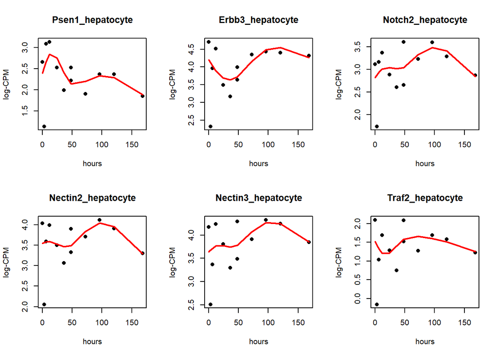

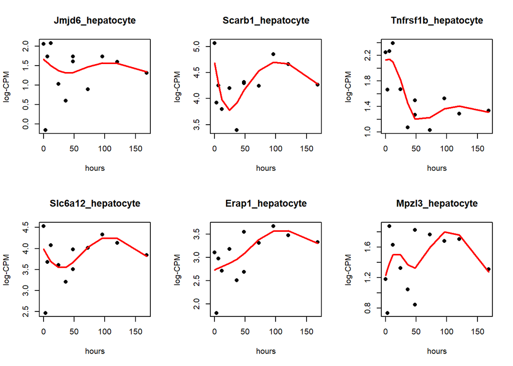

```r
plot_trend(order_receptors, receiver_celltype)
```

## 2) GO terms

```r
# GO <- goana(order_receptors, species = "Mm")
# topgo <- topGO(GO)
```

Trial

```r
# tab = read.csv("C:/Users/pc/Desktop/MastersProject/Dynamic_NicheNet/tab.csv")
# tab["de"] <- rep(0, dim(tab)[1])
```

```r
# GO_genes <- logCPM.fit[which(rownames(logCPM.fit) %in% paste0(order_receptors, "_", receiver_celltype)),]
# tab$de[which(rownames(tab) %in% paste0(order_receptors, "_", receiver_celltype))] <- 1
```

```r
# library(topGO)
# gene_universe <- tab$de
# gene_universe <- factor(gene_universe)
# names(gene_universe) <- rownames(tab)
# head(gene_universe)
```

```r
# go_data <- new("topGOdata",
#                ontology = "BP",
#                allGenes = gene_universe,
#                nodeSize = 5,
#                annotationFun = annFUN.org,
#                mapping = "org.Mm.eg",
#                ID = "symbol")
```